# calling_data

```python
import pandas as pd
import numpy as np
import random
import os
import matplotlib as plt
import seaborn as sns
import matplotlib.pyplot as plt
import matplotlib.font_manager as fm
from matplotlib import rc
import matplotlib.pyplot as plt
import matplotlib.font_manager as fm
import sklearn

# 한글 폰트 경로 설정
font_path = 'C:/Users/jaemi/Downloads/nanum-all/나눔 글꼴/나눔고딕/NanumFontSetup_TTF_GOTHIC/NanumGothic.ttf'
# 폰트 이름 얻어오기
font_name = fm.FontProperties(fname=font_path).get_name()
# 폰트 설정
plt.rcParams['font.family'] = font_name

def seed_everything(seed):
    random.seed(seed)
    os.environ['PYTHONHASHSEED'] = str(seed)
    np.random.seed(seed)

seed_everything(42) # Seed 고정
```

```python
df=pd.read_csv('C:/Users/jaemi/Downloads/open/train.csv')
```

```python
df.head()
```

|  | ID | 가입일 | 음성사서함이용 | 주간통화시간 | 주간통화횟수 | 주간통화요금 | 저녁통화시간 | 저녁통화횟수 | 저녁통화요금 | 밤통화시간 | 밤통화횟수 | 밤통화요금 | 상담전화건수 | 전화해지여부 |
| --- | --- | --- | --- | --- | --- | --- | --- | --- | --- | --- | --- | --- | --- | --- |
| 0 | TRAIN_00000 | 329 | 0 | 99.2 | 93 | 27.3 | 268.8 | 68 | 28.92 | 262.9 | 328 | 32.89 | 2 | 0 |
| 1 | TRAIN_00001 | 2 | 80 | 323.9 | 323 | 83.7 | 269.4 | 326 | 32.09 | 322.8 | 209 | 32.32 | 2 | 0 |
| 2 | TRAIN_00002 | 93 | 28 | 282.4 | 323 | 34.2 | 207.0 | 322 | 32.82 | 280.8 | 328 | 8.28 | 0 | 0 |
| 3 | TRAIN_00003 | 223 | 1 | 221.4 | 223 | 25.1 | 233.0 | 61 | 23.90 | 203.8 | 234 | 9.36 | 0 | 0 |
| 4 | TRAIN_00004 | 222 | 0 | 96.3 | 222 | 28.7 | 223.9 | 69 | 28.08 | 263.1 | 223 | 2.80 | 8 | 0 |

```python
df=df.drop(['ID'],axis=1) #분석에 필요없는 열 삭제
```

```python
df.shape
```

```
(30200, 13)
```

```python
df.dtypes
```

```
가입일          int64
음성사서함이용      int64
주간통화시간     float64
주간통화횟수       int64
주간통화요금     float64
저녁통화시간     float64
저녁통화횟수       int64
저녁통화요금     float64
밤통화시간      float64
밤통화횟수        int64
밤통화요금      float64
상담전화건수       int64
전화해지여부       int64
dtype: object
```

```python
df.info()
```

```
<class 'pandas.core.frame.DataFrame'>
RangeIndex: 30200 entries, 0 to 30199
Data columns (total 13 columns):
 #   Column   Non-Null Count  Dtype
---  ------   --------------  -----
 0   가입일      30200 non-null  int64
 1   음성사서함이용  30200 non-null  int64
 2   주간통화시간   30200 non-null  float64
 3   주간통화횟수   30200 non-null  int64
 4   주간통화요금   30200 non-null  float64
 5   저녁통화시간   30200 non-null  float64
 6   저녁통화횟수   30200 non-null  int64
 7   저녁통화요금   30200 non-null  float64
 8   밤통화시간    30200 non-null  float64
 9   밤통화횟수    30200 non-null  int64
 10  밤통화요금    30200 non-null  float64
 11  상담전화건수   30200 non-null  int64
 12  전화해지여부   30200 non-null  int64
dtypes: float64(6), int64(7)
memory usage: 3.0 MB
```

```python
df.isnull().sum(axis=0) #결측치 없음"
```

```
가입일        0
음성사서함이용    0
주간통화시간     0
주간통화횟수     0
주간통화요금     0
저녁통화시간     0
저녁통화횟수     0
저녁통화요금     0
밤통화시간      0
밤통화횟수      0
밤통화요금      0
상담전화건수     0
전화해지여부     0
dtype: int64
```

```python
df.describe()
```

|  | 가입일 | 음성사서함이용 | 주간통화시간 | 주간통화횟수 | 주간통화요금 | 저녁통화시간 | 저녁통화횟수 | 저녁통화요금 | 밤통화시간 | 밤통화횟수 | 밤통화요금 | 상담전화건수 | 전화해지여부 |
| --- | --- | --- | --- | --- | --- | --- | --- | --- | --- | --- | --- | --- | --- |
| count | 30200.000000 | 30200.000000 | 30200.000000 | 30200.000000 | 30200.000000 | 30200.000000 | 30200.000000 | 30200.000000 | 30200.000000 | 30200.000000 | 30200.000000 | 30200.000000 | 30200.000000 |
| mean | 159.732649 | 12.037815 | 250.563457 | 159.175728 | 41.091447 | 263.247215 | 158.474536 | 25.394260 | 263.438285 | 157.047417 | 12.074648 | 2.288079 | 0.109868 |
| std | 123.752781 | 24.925334 | 84.403350 | 101.573057 | 23.179017 | 74.064922 | 102.200293 | 8.146126 | 73.778416 | 101.721601 | 9.414261 | 2.050746 | 0.312730 |
| min | 1.000000 | 0.000000 | 0.000000 | 0.000000 | 0.000000 | 0.100000 | 0.000000 | 0.000000 | 20.800000 | 20.000000 | 1.040000 | 0.000000 | 0.000000 |
| 25% | 63.000000 | 0.000000 | 222.800000 | 88.000000 | 24.400000 | 223.700000 | 87.000000 | 22.220000 | 223.700000 | 87.000000 | 4.700000 | 2.000000 | 0.000000 |
| 50% | 118.000000 | 1.000000 | 234.000000 | 117.500000 | 30.800000 | 243.000000 | 112.000000 | 23.320000 | 242.800000 | 108.000000 | 9.080000 | 2.000000 | 0.000000 |
| 75% | 228.000000 | 22.000000 | 289.600000 | 223.000000 | 45.900000 | 290.300000 | 223.000000 | 28.820000 | 290.500000 | 222.000000 | 20.290000 | 2.000000 | 0.000000 |
| max | 2212.000000 | 1112.000000 | 481.900000 | 489.000000 | 118.600000 | 481.600000 | 489.000000 | 49.980000 | 481.800000 | 490.000000 | 44.980000 | 11.000000 | 1.000000 |

## feature 별 히스토그램 분포

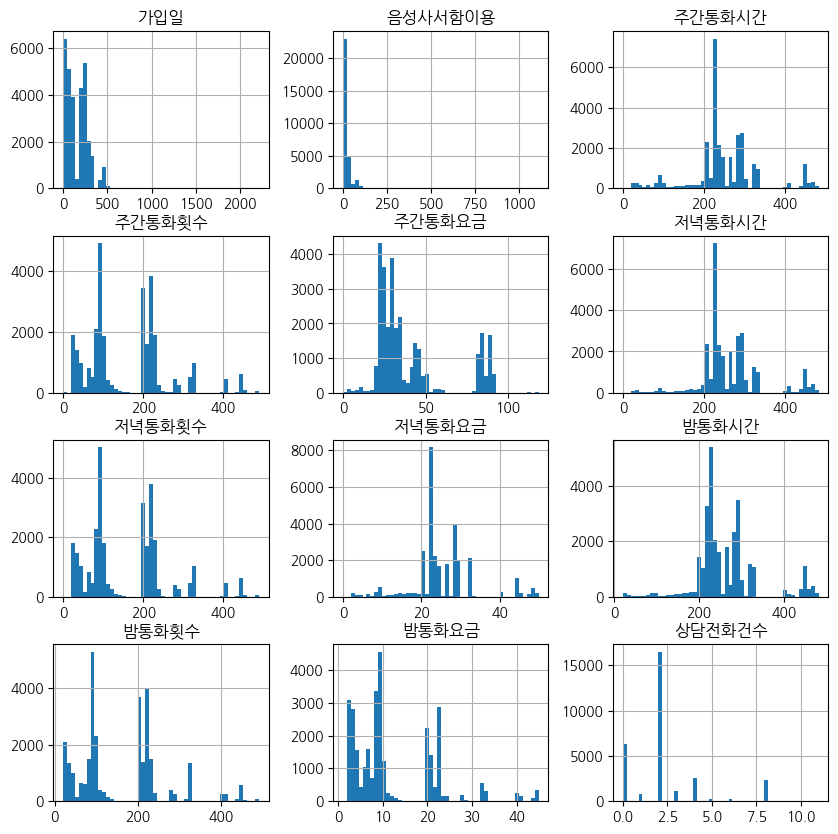

```python
df.drop(['전화해지여부'], axis=1).hist(bins=50, figsize=(10, 10))
plt.show()
```

##### 다른 Feature들에 비해, 가입일과 음성사서이용의 꼬리가 아주 두껍다

##### 이상치를 처리해 모양을 안정화해주면 좋을 것 같다

## 이상치 처리할 변수 boxplot 확인

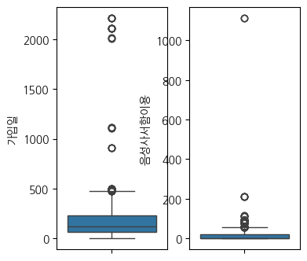

```
Whisker y-values for subplot 1: [1. 1.]
Whisker y-values for subplot 1: [475. 475.]
Whisker y-values for subplot 2: [0. 0.]
Whisker y-values for subplot 2: [55. 55.]
```

```python
fig, ax = plt.subplots(1,2,figsize=(4, 4))
sns.boxplot(df['가입일'], ax=ax[0])
sns.boxplot(df['음성사서함이용'], ax=ax[1])
plt.show()

for i in range(len(ax)):
    whiskers = ax[i].lines[2:4]
    for whisker in whiskers:
        y_data = whisker.get_ydata()
        print(f"Whisker y-values for subplot {i+1}: {y_data}")
```

## 타겟변수 확인

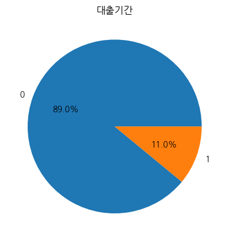

```python
labels0= df['전화해지여부'].value_counts().index.tolist()
fracs0= df['전화해지여부'].value_counts().values.tolist()

plt.pie(fracs0,labels=labels0,autopct='%.1f%%')
plt.title("대출기간")
plt.show()
```

##### 클래스 불균형이 심하다. 이후에 가중치 조정을 해볼 생각이다.|

```python
fracs0
```

```
[26882, 3318]
```

## 상관관계 분석

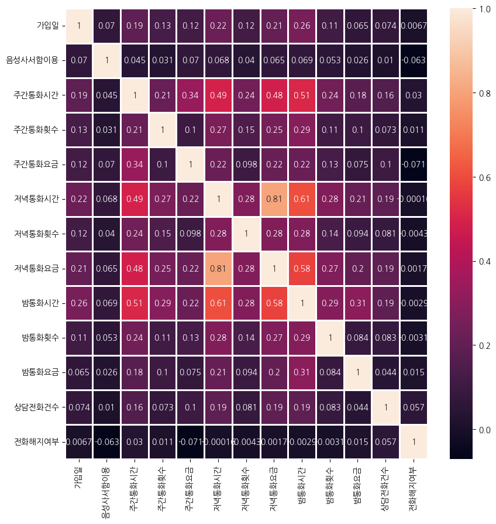

```python
corr_matrix = df.corr()
plt.figure(figsize=(10, 10))
sns.heatmap(corr_matrix, annot=True, linewidth=1)
```

##### 분류모델 돌릴 생각이므로 다중공선성은 따로 고려하지 않기로 함

## train, test 데이터셋 분리

```python
# features/target, train/test dataset 분리
from sklearn.model_selection import train_test_split

feature_columns = list(df.columns.difference(['전화해지여부']))
X = df[feature_columns]
y = df['전화해지여부']

X_train, X_test, y_train, y_test = train_test_split(X, y, test_size = 0.2, random_state = 42) # 학습데이터와 평가데이터의 비율을 8:2 로 분할|
print(X_train.shape, X_test.shape, y_train.shape, y_test.shape) # 데이터 개수 확인
```

```
(24160, 12) (6040, 12) (24160,) (6040,)
```

```python
#decision tree모형

from sklearn.tree import DecisionTreeClassifier
dtc = DecisionTreeClassifier(random_state=0)
dtc.fit(X_train, y_train)
print('모델의 정확도 :', round(dtc.score(X_test, y_test), 4))
```

```
모델의 정확도 : 0.8833
```

## 여러 방법으로 모델 성능 향상시키기

### 이상치 제거

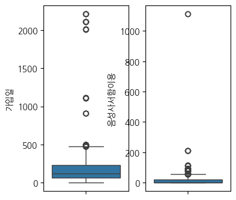

```
Whisker y-values for subplot 1: [1. 1.]
Whisker y-values for subplot 1: [475. 475.]
Whisker y-values for subplot 2: [0. 0.]
Whisker y-values for subplot 2: [55. 55.]
```

```python
fig, ax = plt.subplots(1,2,figsize=(4, 4))
sns.boxplot(df['가입일'], ax=ax[0])
sns.boxplot(df['음성사서함이용'], ax=ax[1])
plt.show()

for i in range(len(ax)):
    whiskers = ax[i].lines[2:4]
    for whisker in whiskers:
        y_data = whisker.get_ydata()
        print(f"Whisker y-values for subplot {i+1}: {y_data}")
```

```python
condition=df['가입일']>475
a=df[condition].index
df.drop(a,inplace=True)
```

```python
condition=df['음성사서함이용']>55
a=df[condition].index
df.drop(a,inplace=True)
```

```python
df
```

|  | 가입일 | 음성사서함이용 | 주간통화시간 | 주간통화횟수 | 주간통화요금 | 저녁통화시간 | 저녁통화횟수 | 저녁통화요금 | 밤통화시간 | 밤통화횟수 | 밤통화요금 | 상담전화건수 | 전화해지여부 |
| --- | --- | --- | --- | --- | --- | --- | --- | --- | --- | --- | --- | --- | --- |
| 0 | 329 | 0 | 99.2 | 93 | 27.3 | 268.8 | 68 | 28.92 | 262.9 | 328 | 32.89 | 2 | 0 |
| 2 | 93 | 28 | 282.4 | 323 | 34.2 | 207.0 | 322 | 32.82 | 280.8 | 328 | 8.28 | 0 | 0 |
| 3 | 223 | 1 | 221.4 | 223 | 25.1 | 233.0 | 61 | 23.90 | 203.8 | 234 | 9.36 | 0 | 0 |
| 4 | 222 | 0 | 96.3 | 222 | 28.7 | 223.9 | 69 | 28.08 | 263.1 | 223 | 2.80 | 8 | 0 |
| 5 | 82 | 32 | 89.5 | 83 | 28.9 | 289.6 | 29 | 32.28 | 270.7 | 323 | 2.26 | 2 | 0 |
| ... | ... | ... | ... | ... | ... | ... | ... | ... | ... | ... | ... | ... | ... |
| 30193 | 232 | 0 | 294.5 | 222 | 40.9 | 244.8 | 203 | 20.22 | 221.6 | 94 | 20.42 | 2 | 0 |
| 30194 | 282 | 30 | 230.7 | 203 | 83.4 | 206.5 | 209 | 22.82 | 292.3 | 223 | 8.66 | 2 | 0 |
| 30197 | 24 | 0 | 222.4 | 33 | 22.1 | 233.9 | 32 | 22.22 | 293.6 | 95 | 4.22 | 2 | 0 |
| 30198 | 63 | 1 | 262.4 | 202 | 29.6 | 280.6 | 282 | 28.88 | 280.9 | 207 | 20.88 | 2 | 1 |
| 30199 | 200 | 1 | 327.1 | 203 | 86.8 | 330.1 | 82 | 28.88 | 289.1 | 323 | 6.28 | 0 | 0 |

28219 rows × 13 columns

```python
# features/target, train/test dataset 분리
from sklearn.model_selection import train_test_split

feature_columns = list(df.columns.difference(['전화해지여부']))
X = df[feature_columns]
y = df['전화해지여부']

X_train, X_test, y_train, y_test = train_test_split(X, y, test_size = 0.2, random_state = 42) # 학습데이터와 평가데이터의 비율을 8:2 로 분할|
print(X_train.shape, X_test.shape, y_train.shape, y_test.shape) # 데이터 개수 확인
```

```
(22575, 12) (5644, 12) (22575,) (5644,)
```

```python
#decision tree모형

from sklearn.tree import DecisionTreeClassifier
dtc = DecisionTreeClassifier(random_state=0)
dtc.fit(X_train, y_train)
print('모델의 정확도 :', round(dtc.score(X_test, y_test), 4))
```

```
모델의 정확도 : 0.8896
```

##### 이상치 제거 후 모델성능 상승 0.8833 -> 0.8896

### 파생변수 추가

```python
df['통화시간/가입일'] = (df['주간통화시간'] + df['저녁통화시간'] + df['밤통화시간'] ) / df['가입일']

df['통화횟수/가입일'] = ( df['주간통화횟수'] + df['저녁통화횟수'] + df['밤통화횟수'] ) / df['가입일']

df['통화요금/가입일'] = (df['주간통화요금'] + df['저녁통화요금'] + df['밤통화요금'] ) / df['가입일']

df['총통화시간'] = df['주간통화시간'] + df['저녁통화시간'] + df['밤통화시간']

df['총통화횟수'] = df['주간통화횟수'] + df['저녁통화횟수'] + df['밤통화횟수']

df['총통화요금'] = df['주간통화요금'] + df['저녁통화요금'] + df['밤통화요금']

df['상담전화건수/통화시간'] = df['상담전화건수'] / (df['주간통화시간'] + df['저녁통화시간'] + df['밤통화시간'] )

df['Max통화시간'] = df[['주간통화시간','저녁통화시간', '밤통화시간']].max(axis=1)

df['Min통화시간'] = df[['주간통화시간','저녁통화시간', '밤통화시간']].min(axis=1)

df['Diff통화시간'] = df['Max통화시간'] - df['Min통화시간']
```

```python
# features/target, train/test dataset 분리
from sklearn.model_selection import train_test_split

feature_columns = list(df.columns.difference(['전화해지여부']))
X = df[feature_columns]
y = df['전화해지여부']

X_train, X_test, y_train, y_test = train_test_split(X, y, test_size = 0.2, random_state = 42) # 학습데이터와 평가데이터의 비율을 8:2 로 분할|
print(X_train.shape, X_test.shape, y_train.shape, y_test.shape) # 데이터 개수 확인
```

```
(22575, 22) (5644, 22) (22575,) (5644,)
```

```python
#decision tree모형

from sklearn.tree import DecisionTreeClassifier
dtc = DecisionTreeClassifier(random_state=0)
dtc.fit(X_train, y_train)
print('모델의 정확도 :', round(dtc.score(X_test, y_test), 4))
```

```
모델의 정확도 : 0.8919
```

##### 파생변수 추가 후 모형 정확도 상승 0.8896 -> 0.8919

### 데이터 스케일링

##### (1) StandardScaler()

```python
from sklearn.preprocessing import StandardScaler

std = StandardScaler()
std.fit(X_train)
X_train_scaled = std.transform(X_train)
X_test_scaled = std.transform(X_test)
dtc.fit(X_train_scaled, y_train)
print('모델의 정확도 :', round(dtc.score(X_test_scaled, y_test), 4))
```

```
모델의 정확도 : 0.8917
```

##### (2) MinMaxScaler()

```python
from sklearn.preprocessing import MinMaxScaler

mms = MinMaxScaler()
mms.fit(X_train)
X_train_scaled = mms.transform(X_train)
X_test_scaled = mms.transform(X_test)
dtc.fit(X_train_scaled, y_train)
print('모델의 정확도 :', round(dtc.score(X_test_scaled, y_test), 4))
```

```
모델의 정확도 : 0.8921
```

##### (3) MaxAbsScaler()

```python
from sklearn.preprocessing import MaxAbsScaler

mas = MaxAbsScaler()
mas.fit(X_train)
X_train_scaled = mas.transform(X_train)
X_test_scaled = mas.transform(X_test)
dtc.fit(X_train_scaled, y_train)
print('모델의 정확도 :', round(dtc.score(X_test_scaled, y_test), 4))
```

```
모델의 정확도 : 0.8921
```

##### (4) RobustScaler()

```python
from sklearn.preprocessing import RobustScaler

rbs = RobustScaler()
X_train_scaled = rbs.fit_transform(X_train)
X_test_scaled = rbs.transform(X_test)
dtc.fit(X_train_scaled, y_train)
print('모델의 정확도 :', round(dtc.score(X_test_scaled, y_test), 4))
```

```
모델의 정확도 : 0.8919
```

##### (5) Normalizer()

```python
from sklearn.preprocessing import Normalizer

norm = Normalizer()
X_train_scaled = norm.fit_transform(X_train)
X_test_scaled = norm.transform(X_test)
dtc.fit(X_train_scaled, y_train)
print('모델의 정확도 :', round(dtc.score(X_test_scaled, y_test), 4))
```

```
모델의 정확도 : 0.8785
```

##### 2) 3) 방법의 스케일링 후 약간의 성능 향상 0.8919 -> 0.8921

##### minmax 스케일러와 maxabs스케일러가 이상치에 민감한 방법임. 이상치 제거를 해준 뒤 스케일러를 진행했기에 정확도 상승이 일어난것이 아닌가 생각이 듬

##### 성능 향상이 일어났던 두가지 스케일러 방법 중 많이 쓰이는 minmax 스케일러 적용 후 분석 진행하기로 함

### pca

##### 성능향상이 일어났던 이상치제거, 파생변수 추가, min-max 스케일러 적용 후 pca 진행

```python
from sklearn.decomposition import PCA
from sklearn.preprocessing import StandardScaler
```

```python
temp = df.drop(['전화해지여부'], axis=1)
temp
```

|  | 가입일 | 음성사서함이용 | 주간통화시간 | 주간통화횟수 | 주간통화요금 | 저녁통화시간 | 저녁통화횟수 | 저녁통화요금 | 밤통화시간 | 밤통화횟수 | ... | 통화시간/가입일 | 통화횟수/가입일 | 통화요금/가입일 | 총통화시간 | 총통화횟수 | 총통화요금 | 상담전화건수/통화시간 | Max통화시간 | Min통화시간 | Diff통화시간 |
| --- | --- | --- | --- | --- | --- | --- | --- | --- | --- | --- | --- | --- | --- | --- | --- | --- | --- | --- | --- | --- | --- |
| 0 | 329 | 0 | 99.2 | 93 | 27.3 | 268.8 | 68 | 28.92 | 262.9 | 328 | ... | 1.917629 | 1.486322 | 0.270851 | 630.9 | 489 | 89.11 | 0.003170 | 268.8 | 99.2 | 169.6 |
| 2 | 93 | 28 | 282.4 | 323 | 34.2 | 207.0 | 322 | 32.82 | 280.8 | 328 | ... | 8.281720 | 10.462366 | 0.809677 | 770.2 | 973 | 75.30 | 0.000000 | 282.4 | 207.0 | 75.4 |
| 3 | 223 | 1 | 221.4 | 223 | 25.1 | 233.0 | 61 | 23.90 | 203.8 | 234 | ... | 2.951570 | 2.322870 | 0.261704 | 658.2 | 518 | 58.36 | 0.000000 | 233.0 | 203.8 | 29.2 |
| 4 | 222 | 0 | 96.3 | 222 | 28.7 | 223.9 | 69 | 28.08 | 263.1 | 223 | ... | 2.627477 | 2.315315 | 0.268378 | 583.3 | 514 | 59.58 | 0.013715 | 263.1 | 96.3 | 166.8 |
| 5 | 82 | 32 | 89.5 | 83 | 28.9 | 289.6 | 29 | 32.28 | 270.7 | 323 | ... | 7.924390 | 5.304878 | 0.773659 | 649.8 | 435 | 63.44 | 0.003078 | 289.6 | 89.5 | 200.1 |
| ... | ... | ... | ... | ... | ... | ... | ... | ... | ... | ... | ... | ... | ... | ... | ... | ... | ... | ... | ... | ... | ... |
| 30193 | 232 | 0 | 294.5 | 222 | 40.9 | 244.8 | 203 | 20.22 | 221.6 | 94 | ... | 3.279741 | 2.237069 | 0.351466 | 760.9 | 519 | 81.54 | 0.002628 | 294.5 | 221.6 | 72.9 |
| 30194 | 282 | 30 | 230.7 | 203 | 83.4 | 206.5 | 209 | 22.82 | 292.3 | 223 | ... | 2.586879 | 2.251773 | 0.407376 | 729.5 | 635 | 114.88 | 0.002742 | 292.3 | 206.5 | 85.8 |
| 30197 | 24 | 0 | 222.4 | 33 | 22.1 | 233.9 | 32 | 22.22 | 293.6 | 95 | ... | 31.245833 | 6.666667 | 2.022500 | 749.9 | 160 | 48.54 | 0.002667 | 293.6 | 222.4 | 71.2 |
| 30198 | 63 | 1 | 262.4 | 202 | 29.6 | 280.6 | 282 | 28.88 | 280.9 | 207 | ... | 13.077778 | 10.968254 | 1.259683 | 823.9 | 691 | 79.36 | 0.002427 | 280.9 | 262.4 | 18.5 |
| 30199 | 200 | 1 | 327.1 | 203 | 86.8 | 330.1 | 82 | 28.88 | 289.1 | 323 | ... | 4.731500 | 3.040000 | 0.609800 | 946.3 | 608 | 121.96 | 0.000000 | 330.1 | 289.1 | 41.0 |

28219 rows × 22 columns

```python
#스케일러 적용
scaler = MinMaxScaler()
temp = scaler.fit_transform(temp)
temp
```

```
array([[0.69198312, 0.        , 0.20585184, ..., 0.43309391, 0.20857864,
        0.35615288],
       [0.19409283, 0.50909091, 0.5860137 , ..., 0.46927374, 0.4352397 ,
        0.15833683],
       [0.46835443, 0.01818182, 0.45943142, ..., 0.33785581, 0.42851135,
        0.06131877],
       ...,
       [0.04852321, 0.        , 0.46150654, ..., 0.4990689 , 0.46761985,
        0.14951701],
       [0.13080169, 0.01818182, 0.54451131, ..., 0.46528332, 0.55172414,
        0.03884922],
       [0.41983122, 0.01818182, 0.67877153, ..., 0.59616919, 0.60786375,
        0.08609828]])
```

```python
pca = PCA()
pca.fit(temp)
```

```
PCA()
```

```python
print(pca.explained_variance_)
print(pca.explained_variance_ratio_)
```

```
[1.94520288e-01 5.85579735e-02 5.60024118e-02 4.92248112e-02
 4.73472223e-02 4.45438649e-02 4.13373321e-02 3.84246513e-02
 3.56325750e-02 3.12486807e-02 1.55438519e-02 1.01406089e-02
 5.11504165e-03 3.09146066e-03 6.62576372e-04 4.36286237e-04
 1.16192376e-04 6.51327988e-05 3.07993026e-31 1.40876518e-31
 8.70333035e-32 2.02950615e-32]
[3.07779928e-01 9.26534143e-02 8.86098742e-02 7.78860087e-02
 7.49151916e-02 7.04795765e-02 6.54060366e-02 6.07974443e-02
 5.63796787e-02 4.94432575e-02 2.45942758e-02 1.60449890e-02
 8.09327995e-03 4.89146684e-03 1.04836215e-03 6.90314351e-04
 1.83845507e-04 1.03056438e-04 4.87322286e-31 2.22902016e-31
 1.37708535e-31 3.21118822e-32]
```

```python
sum = 0
for i, ratio in enumerate(pca.explained_variance_ratio_):
    sum += ratio
    print(f'{sum} by PCA{i+1}')
```

```
0.30777992756625777 by PCA1
0.40043334187460605 by PCA2
0.48904321606814255 by PCA3
0.5669292247510017 by PCA4
0.6418444163331921 by PCA5
0.7123239928108138 by PCA6
0.77773002938923 by PCA7
0.8385274737161844 by PCA8
0.8949071524659711 by PCA9
0.9443504099886175 by PCA10
0.9689446857869493 by PCA11
0.9849896747550083 by PCA12
0.9930829547094954 by PCA13
0.9979744215518461 by PCA14
0.9990227837036654 by PCA15
0.9997130980545075 by PCA16
0.9998969435615402 by PCA17
1.0000000000000002 by PCA18
1.0000000000000002 by PCA19
1.0000000000000002 by PCA20
1.0000000000000002 by PCA21
1.0000000000000002 by PCA22
```

##### 분산비율 임계치를 대략 90%로 잡고 10차원으로 줄여서 모델성능 확인

```python
#10차원으로 차원 축소
pca=PCA(n_components=10)
pca.fit(temp)
df_pca=pca.transform(temp)

pca_columns=['pca_component_1','pca_component_2','pca_component_3','pca_component_4','pca_component_5','pca_component_6','pca_component_7','pca_component_8','pca_component_9','pca_component_10']
df_pca=pd.DataFrame(df_pca,columns=pca_columns)
df_pca.head()
```

|  | pca_component_1 | pca_component_2 | pca_component_3 | pca_component_4 | pca_component_5 | pca_component_6 | pca_component_7 | pca_component_8 | pca_component_9 | pca_component_10 |
| --- | --- | --- | --- | --- | --- | --- | --- | --- | --- | --- |
| 0 | -0.053491 | -0.062622 | 0.224787 | -0.263700 | -0.123456 | 0.496448 | 0.091357 | 0.608859 | 0.051067 | 0.062288 |
| 1 | 0.250252 | 0.574600 | 0.286130 | 0.434879 | -0.031395 | 0.151809 | -0.138541 | -0.105907 | 0.026023 | -0.130557 |
| 2 | -0.195876 | 0.038022 | 0.157219 | 0.014460 | -0.289500 | -0.022337 | -0.112396 | 0.131248 | 0.245436 | -0.165947 |
| 3 | -0.249058 | -0.138755 | 0.514053 | -0.386261 | 0.610528 | 0.022397 | 0.027931 | 0.076614 | 0.230567 | 0.059254 |
| 4 | -0.290524 | 0.482033 | 0.036121 | 0.013779 | 0.265507 | 0.121158 | -0.264409 | 0.280158 | 0.184606 | 0.416020 |

```python
# features/target, train/test dataset 분리

feature_columns = list(df_pca.columns)
X_pca = df_pca[feature_columns]
y_pca = df['전화해지여부']

X_train_pca, X_test_pca, y_train_pca, y_test_pca = train_test_split(X_pca, y_pca, test_size = 0.2, random_state = 42) # 학습데이터와 평가데이터의 비율을 8:2 로 분할|
print(X_train_pca.shape, X_test_pca.shape, y_train_pca.shape, y_test_pca.shape) # 데이터 개수 확인
```

```
(22575, 10) (5644, 10) (22575,) (5644,)
```

```python
#decision tree모형

from sklearn.tree import DecisionTreeClassifier
dtc = DecisionTreeClassifier(random_state=0)
dtc.fit(X_train_pca, y_train_pca)
print('모델의 정확도 :', round(dtc.score(X_test_pca, y_test_pca), 4))
```

```
모델의 정확도 : 0.8758
```

##### 원본데이터의 손실이 일어난만큼 학습을 잘 하지못해 성능이 떨어졌다고 생각

### 불균형 클래스 조정

##### 일반적으로 언더샘플링보다 오버샘플링 방법이 예측상 유리

##### 주의할점은 반드시 학습 데이터 세트만 오버샘플링을 해야한다.

##### 이전에 성능향상이 있었던 파생변수 생성, min_max scaler 이후 class weight 조정 진행

```python
# features/target, train/test dataset 분리
from sklearn.model_selection import train_test_split

feature_columns = list(df.columns.difference(['전화해지여부']))
X = df[feature_columns]
y = df['전화해지여부']

X_train, X_test, y_train, y_test = train_test_split(X, y, test_size = 0.2, random_state = 42) # 학습데이터와 평가데이터의 비율을 8:2 로 분할|
print(X_train.shape, X_test.shape, y_train.shape, y_test.shape) # 데이터 개수 확인
```

```
(22575, 22) (5644, 22) (22575,) (5644,)
```

```python
#scaler 적용
from sklearn.preprocessing import MinMaxScaler

mms = MinMaxScaler()
mms.fit(X_train)
X_train_scaled = mms.transform(X_train)
X_test_scaled = mms.transform(X_test)
dtc.fit(X_train_scaled, y_train)
print('모델의 정확도 :', round(dtc.score(X_test_scaled, y_test), 4))
```

```
모델의 정확도 : 0.8921
```

#### smote 알고리즘

```python
from imblearn.over_sampling import SMOTE
X_resampled, y_resampled = SMOTE(random_state=0).fit_resample(X_train_scaled, y_train)
```

```python
y_resampled.value_counts()
```

```
전화해지여부
0    20005
1    20005
Name: count, dtype: int64
```

##### 라벨 분포를 다시 살펴보면 균등한 개수로 오버 샘플링되어 맞추어져있음

```python
#decision tree모형

from sklearn.tree import DecisionTreeClassifier
dtc = DecisionTreeClassifier(random_state=0)
dtc.fit(X_resampled, y_resampled)
print('모델의 정확도 :', round(dtc.score(X_test_scaled, y_test), 4))
```

```
모델의 정확도 : 0.8382
```

##### 모델성능 하락함. 다른 알고리즘 적용해보자

#### ADASYN 알고리즘

```python
from imblearn.over_sampling import ADASYN
X_resampled, y_resampled = ADASYN(random_state=0).fit_resample(X_train_scaled, y_train)
```

```python
y_resampled.value_counts()
```

```
전화해지여부
0    20005
1    19270
Name: count, dtype: int64
```

```python
#decision tree모형

from sklearn.tree import DecisionTreeClassifier
dtc = DecisionTreeClassifier(random_state=0)
dtc.fit(X_resampled, y_resampled)
print('모델의 정확도 :', round(dtc.score(X_test_scaled, y_test), 4))
```

```
모델의 정확도 : 0.8356
```

##### 마찬가지로 성능 하락

#### SMOTE+ENN 방법

##### SMOTE(Synthetic Minority Over-sampling Technique) 방법과 ENN(Edited Nearest Neighbours) 방법을 섞은 것

```python
from imblearn.combine import *
```

```python
X_resampled, y_resampled = SMOTEENN(random_state=0).fit_resample(X_train_scaled, y_train)
```

```python
#decision tree모형

from sklearn.tree import DecisionTreeClassifier
dtc = DecisionTreeClassifier(random_state=0)
dtc.fit(X_resampled, y_resampled)
print('모델의 정확도 :', round(dtc.score(X_test_scaled, y_test), 4))
```

```
모델의 정확도 : 0.8056
```

##### 마찬가지로 성능하락

#### SMOTE+Tomek

##### SMOTE(Synthetic Minority Over-sampling Technique) 방법과 토멕링크 방법을 섞은 것

```python
X_resampled, y_resampled = SMOTETomek(random_state=0).fit_resample(X_train_scaled, y_train)
```

```python
#decision tree모형

from sklearn.tree import DecisionTreeClassifier
dtc = DecisionTreeClassifier(random_state=0)
dtc.fit(X_resampled, y_resampled)
print('모델의 정확도 :', round(dtc.score(X_test_scaled, y_test), 4))
```

```
모델의 정확도 : 0.8482
```

##### 마찬가지로 성능하락

##### 위의 알고리즘을 통한 오버샘플링 방법은 클래스의 비중이 비슷해질때까지 계속 데이터를 생성한다.

##### 때문에 심하게 불균형한 데이터의 비중을 맞추기 위해 과하게 데이터를 생성하다보니 모델 성능이 오히려 떨어지는 결과가 생긴게 아닐까 싶다.

##### 따라서 데이터를 생성하지 않고 소수의 클래스에 가중치를 더 많이 주는 방법을 사용해보고자 했다.

### cost-sensitive learning 방법

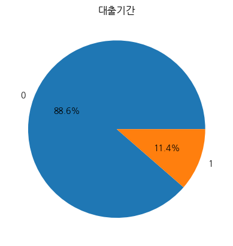

```python
labels0= y_train.value_counts().index.tolist()
fracs0= y_train.value_counts().values.tolist()

plt.pie(fracs0,labels=labels0,autopct='%.1f%%')
plt.title("대출기간")
plt.show()
```

```python
fracs0
```

```
[20005, 2570]
```

```python
fracs0[0]
```

```
20005
```

```python
fracs0[0]/(fracs0[0]+fracs0[1])
```

```
0.886157253599114
```

```python
fracs0[1]/(fracs0[0]+fracs0[1])
```

```
0.11384274640088593
```

```python
(fracs0[0]/(fracs0[0]+fracs0[1]))/(fracs0[1]/(fracs0[0]+fracs0[1]))
```

```
7.784046692607004
```

```python
weights={0:0.11384274640088593, 1:0.886157253599114}
```

```python
dtc = DecisionTreeClassifier(random_state=0,class_weight=weights)
dtc.fit(X_train_scaled, y_train)
print('모델의 정확도 :', round(dtc.score(X_test_scaled, y_test), 4))
```

```
모델의 정확도 : 0.8878
```

##### 참고로 0과 1의 비중을 똑같이 맞추도록 계산해서 cost-sensitive learning에 적용을 해봤으나 정확도가 떨어졌다.

### gridsearchcv를 통한 하이퍼 파라미터 튜닝

```python
from sklearn.model_selection import GridSearchCV
```

```python
classifier = DecisionTreeClassifier(random_state=0)
param_grid = {
    'class_weight': ['balanced', None],
    'criterion': ['gini', 'entropy'],
    'max_depth': [3, 5, 7, 9],
    'min_samples_split': [x for x in range(3, 15,2)],
    'min_samples_leaf': [x for x in range(1, 15,2)],
    'max_features': ['auto', 'sqrt', 'log2'],
    'class_weight': ['balanced', None],
    'splitter': ['best', 'random']
}

# GridSearchCV를 사용하여 최적의 파라미터 찾기
grid_search = GridSearchCV(classifier, param_grid, cv=5)
grid_search.fit(X_train_scaled, y_train)

# 최적의 파라미터와 성능 출력
print("Best parameters:", grid_search.best_params_)
print("Best score:", grid_search.best_score_)
```

```
Best parameters: {'class_weight': None, 'criterion': 'entropy', 'max_depth': 5, 'max_features': 'sqrt', 'min_samples_leaf': 5, 'min_samples_split': 3, 'splitter': 'random'}
Best score: 0.8874861572535991
```

##### 몇가지 의사결정나무모델에서 주요한 파라미터를 가지고 최적의 모델을 찾아보려 했지만 오히려 성능이 떨어졌다.

##### 파라미터에 대한 이해가 부족했다고 생각한다. 이후에 더 보완해볼 생각이다.